# Inferência: testes de permutação e p-valores

Nazareno Andrade

# Intro

Técnicas de Reamostragem = {Bootstrap, Permutação, (jacknifing), …}

Disclaimer: em princípio tudo pode ser feito através de ICs, porém você verá e ouvirá falar muito de p-valores e testes como t-test, mann-withney, wilcoxon e Chi-squared. Então falaremos deles também.

## Os dados

```r
glimpse(ratings)
```

```
Observations: 105,343
Variables: 6
$ userId    <chr> "1", "1", "1", "1", "1", "1", "1", ...
$ movieId   <chr> "16", "24", "32", "47", "50", "110"...
$ rating    <dbl> 4.0, 1.5, 4.0, 4.0, 4.0, 4.0, 3.0, ...
$ timestamp <int> 1217897793, 1217895807, 1217896246,...
$ title     <chr> "Casino (1995)", "Powder (1995)", "...
$ genres    <chr> "Crime|Drama", "Drama|Sci-Fi", "Mys...
```

Focaremos em alguns episódios de Star Wars

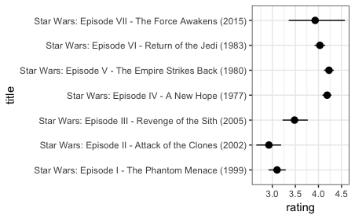

# Nosso framework

## Manual

Vamos guardar as diferenças observadas na nossa amostra para o episódio 5 x 6.

```r
diff.media.observada.5x6
```

```
[1] -0.1965386
```

Mesma coisa para o episódio 4 x 5.

```r
medias4x5 = sw4x5 %>%
  group_by(title) %>%
  summarise(media = mean(rating))
medias4x5
```

| title | media |
| --- | --- |
| Star Wars: Episode IV - A New Hope (1977) | 4.188645 |
| Star Wars: Episode V - The Empire Strikes Back (1980) | 4.228070 |

```r
diff.media.observada.4x5 = diff(medias4x5$media)
```

Agora vejamos o quão frequente seria encontrarmos uma diferença do tamanho que encontramos *se não houvesse associação nenhuma entre qual é o episódio e qual é a avaliação que ele recebe*. A situação onde não existe associação é a *hipótese nula*. Se a diferença que observamos em nossa amostra acontece facilmente na hipótese nula, isso significa que não temos evidência forte de associação: o que observamos acontece também quando não há associação.

No caso onde a diferença que observamos é improvável na hipótese nula, então observamos algo que é indicativo de associação. Repare que é uma dupla negação: se **não acontece** associação como a que vimos na amostra na situação onde **não** há associação, então temos evidência de que há associação.

```r
sum(abs(diffs) >= abs(diff.media.observada.1x4)) / length(diffs)
```

```
[1] 0.0166
```

Episódio 4 x 5

```r
sum(abs(diffs) > abs(diff.media.observada.4x5)) / length(diffs)
```

```
[1] 0.603
```

## Pacote coin

Teste da média

```r
pt$stats$PValue
```

```
[1] 0.4702
```

Teste de que a mediana das populações de onde vieram as avaliações dos episódios são diferentes:

```r
median_test(rating ~ as.factor(title),
            data = sw5x6,
            distribution = "exact")
```

```
    Exact Two-Sample Brown-Mood Median Test

data:  rating by
     as.factor(title) (Star Wars: Episode V - The Empire Strikes Back (1980), Star Wars: Episode VI - Return of the Jedi (1983))
Z = 1.8238, p-value = 0.0725
alternative hypothesis: true mu is not equal to 0
```

## Por que two-tailed

Normalmente estamos interessados em rejeitar a hipótese nula da igualdade. A igualdade está em torno do zero, e portanto a rejeição acontece quando o valor observado está longe de zero em qualquer direção. Existem testes one-tailed que não dão informação sobre se há diferença nas duras direções. Porém na prática é uma prática requerida que você decida o teste antes de realizá-lo, e é difícil decidir que apenas diferenças em uma direção serão relevantes. Além disso, devido à pressão por resultado, decidir usar one-tailed é sempre um truque que aumenta sua chance de produzir um teste com diferença significativa, o que é claramente uma manipulação na sua metodologia.

# Testes conhecidos que você pode encontrar

## Mann-withney-wilcoxon

Testa se a soma dos ranks das duas amostras são significativamente diferentes.

```r
wilcox_test(rating ~ as.factor(title),
            data = sw5x6,
            distribution = "exact") # tirando este parâmetro, usamos fórmula fechada em lugar de permutação
```

```
    Exact Wilcoxon-Mann-Whitney Test

data:  rating by
     as.factor(title) (Star Wars: Episode V - The Empire Strikes Back (1980), Star Wars: Episode VI - Return of the Jedi (1983))
Z = 2.5638, p-value = 0.01027
alternative hypothesis: true mu is not equal to 0
```

## Chi-squared para associação entre duas variávies categóricas

```r
chisq.test(titanic$Survived, titanic$Pclass, simulate.p.value = TRUE)$resid
```

```
                titanic$Pclass
titanic$Survived         1         2         3
               0 -4.601993 -1.537771  3.993703
               1  5.830678  1.948340 -5.059981
```

Outro

```r
chisq.test(titanic2$sex, titanic2$survival, simulate.p.value = TRUE)
```

```
    Pearson's Chi-squared test with simulated p-value (based on 2000 replicates)

data:  titanic2$sex and titanic2$survival
X-squared = 460.87, df = NA, p-value = 0.0004998
```

## Outra alternativa: pacote resample

Os p-valores dão diferente daqueles calculados pelo pacote `coin`, e ainda não descobri a razão exata.

```r
library(resample)

permutationTest2(data = sw5x6, statistic = mean(rating), treatment = title)

permutationTest2(data = sw5x6 %>% filter(title == nomes_episodios[6]),
                 statistic = mean(rating),
                 data2 = sw5x6 %>% filter(title == nomes_episodios[5]))

permutationTest2(sw4x5, mean(rating), treatment = title)

permutationTest2(sw1x4, median(rating), treatment = title)
permutationTest2(sw4x5, median(rating), treatment = title)
```

[output not shown]